# Regresja

Rafał Lisak & Michał Grzybek

6 06 2021

```r
dataset <- read.csv("student-por.csv", sep = ';', header = TRUE)
dataset <- subset(dataset, select = -c(G1, G2))#wyrzucamy oceny semestralny, gdyż w oczywisty sposób są najbardziej znaczące dla oceny końcowej
```

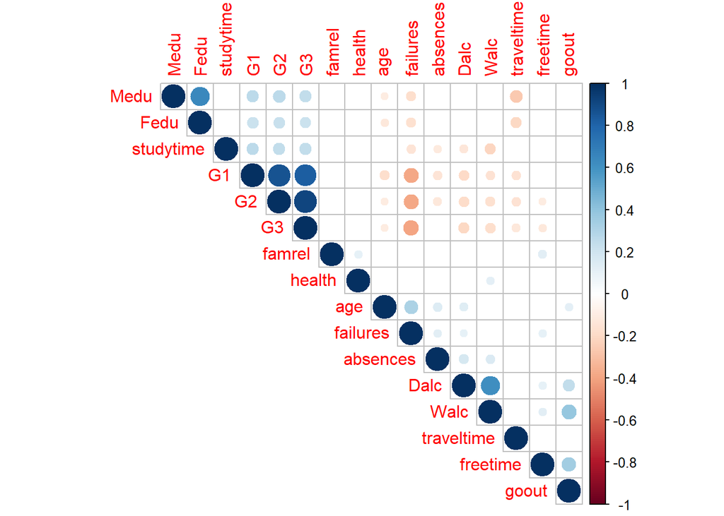

```r
data_raw<-read.csv('student-por.csv', sep = ';',header = TRUE,stringsAsFactors = TRUE)
num<-dplyr::select(data_raw, age, Medu, Fedu, traveltime, studytime, failures, famrel, freetime, goout,Dalc, Walc,health,absences, G1,G2,G3)
res<-Hmisc::rcorr(as.matrix(num))

corrplot(res$r, type="upper", order="hclust",
         p.mat = res$P, sig.level = 0.01, insig = "blank")
```

```r
head(data_raw)
```

```
##   school sex age address famsize Pstatus Medu Fedu     Mjob     Fjob     reason
## 1     GP   F  18       U     GT3       A    4    4  at_home  teacher     course
## 2     GP   F  17       U     GT3       T    1    1  at_home    other     course
## 3     GP   F  15       U     LE3       T    1    1  at_home    other      other
## 4     GP   F  15       U     GT3       T    4    2   health services       home
## 5     GP   F  16       U     GT3       T    3    3    other    other       home
## 6     GP   M  16       U     LE3       T    4    3 services    other reputation
##   guardian traveltime studytime failures schoolsup famsup paid activities
## 1   mother          2         2        0       yes     no   no         no
## 2   father          1         2        0        no    yes   no         no
## 3   mother          1         2        0       yes     no   no         no
## 4   mother          1         3        0        no    yes   no        yes
## 5   father          1         2        0        no    yes   no         no
## 6   mother          1         2        0        no    yes   no        yes
##   nursery higher internet romantic famrel freetime goout Dalc Walc health
## 1     yes    yes       no       no      4        3     4    1    1      3
## 2      no    yes      yes       no      5        3     3    1    1      3
## 3     yes    yes      yes       no      4        3     2    2    3      3
## 4     yes    yes      yes      yes      3        2     2    1    1      5
## 5     yes    yes       no       no      4        3     2    1    2      5
## 6     yes    yes      yes       no      5        4     2    1    2      5
##   absences G1 G2 G3
## 1        4  0 11 11
## 2        2  9 11 11
## 3        6 12 13 12
## 4        0 14 14 14
## 5        0 11 13 13
## 6        6 12 12 13
```

Na podstawie macierzy kowariancji wyrzucamy G2, oraz G1, gdyż są to wartości skorelowane z G3.

```r
data_raw <- data_raw  %>% dplyr::select(-G1)
data_raw <- data_raw  %>% dplyr::select(-G2)
data_classification <- data_raw
str(data_classification)
```

```
## 'data.frame':    649 obs. of  31 variables:
##  $ school    : Factor w/ 2 levels "GP","MS": 1 1 1 1 1 1 1 1 1 1 ...
##  $ sex       : Factor w/ 2 levels "F","M": 1 1 1 1 1 2 2 1 2 2 ...
##  $ age       : int  18 17 15 15 16 16 16 17 15 15 ...
##  $ address   : Factor w/ 2 levels "R","U": 2 2 2 2 2 2 2 2 2 2 ...
##  $ famsize   : Factor w/ 2 levels "GT3","LE3": 1 1 2 1 1 2 2 1 2 1 ...
##  $ Pstatus   : Factor w/ 2 levels "A","T": 1 2 2 2 2 2 2 1 1 2 ...
##  $ Medu      : int  4 1 1 4 3 4 2 4 3 3 ...
##  $ Fedu      : int  4 1 1 2 3 3 2 4 2 4 ...
##  $ Mjob      : Factor w/ 5 levels "at_home","health",..: 1 1 1 2 3 4 3 3 4 3 ...
##  $ Fjob      : Factor w/ 5 levels "at_home","health",..: 5 3 3 4 3 3 3 5 3 3 ...
##  $ reason    : Factor w/ 4 levels "course","home",..: 1 1 3 2 2 4 2 2 2 2 ...
##  $ guardian  : Factor w/ 3 levels "father","mother",..: 2 1 2 2 1 2 2 2 2 2 ...
##  $ traveltime: int  2 1 1 1 1 1 1 2 1 1 ...
##  $ studytime : int  2 2 2 3 2 2 2 2 2 2 ...
```

[output cut: 17 more lines]

```r
#Współczynniki numeryczne możemy przeskalować
data_classification[, c("age", "Medu", "Fedu", "traveltime", "studytime", "failures", "famrel", "freetime", "goout", "Dalc", "Walc", "health", "absences", "G3")] <- scale(data_classification[, c("age", "Medu", "Fedu", "traveltime", "studytime", "failures", "famrel", "freetime", "goout", "Dalc", "Walc", "health", "absences", "G3")])
```

```r
#Współczynniki odpowiadające tak lub nie możemy łatwo zamienić na wartości binarne
data_classification$schoolsup <- ifelse(data_classification$schoolsup == "yes", 1, 0)
data_classification$famsup <- ifelse(data_classification$famsup == "yes", 1, 0)
data_classification$paid <- ifelse(data_classification$paid == "yes", 1, 0)
data_classification$activities <- ifelse(data_classification$activities == "yes", 1, 0)
data_classification$nursery <- ifelse(data_classification$nursery == "yes", 1, 0)
data_classification$higher <- ifelse(data_classification$higher == "yes", 1, 0)
data_classification$internet <- ifelse(data_classification$internet == "yes", 1, 0)
data_classification$romantic <- ifelse(data_classification$romantic == "yes", 1, 0)
```

```r
#Współczynniki posiadające dwa poziomy nie możemy zmienić na binarne ponieważ tracilibyśmy informacje i mobilbyśmy uzyskać błędne relacje. Rozdzielamy je na osobne kolumny.
data_classification$school <- dummy.code(data_classification$school)
data_classification$address <- dummy.code(data_classification$address)
data_classification$famsize <- dummy.code(data_classification$famsize)
data_classification$Pstatus <- dummy.code(data_classification$Pstatus)
data_classification$sex <- dummy.code(data_classification$sex)
```

```r
#Współczynniki posiadające więcej niż dwa poziomy też rozdzielamy na binarne kolumny ale przedtym zmieniamy ich nazwy żeby się nie powtarzały.
Fjob <- as.data.frame(dummy.code(data_classification$Fjob))
Mjob <- as.data.frame(dummy.code(data_classification$Mjob))
reason <- as.data.frame(dummy.code(data_classification$reason))
guardian <- as.data.frame(dummy.code(data_classification$guardian))
```

```r
Fjob <- rename(Fjob, services_Fjob = services)
Fjob <- rename(Fjob, at_home_Fjob = at_home)
Fjob <- rename(Fjob, teacher_Fjob = teacher)
Mjob <- rename(Mjob, services_Mjob = services)
Mjob <- rename(Mjob, at_home_Mjob = at_home)
Mjob <- rename(Mjob, teacher_Mjob = teacher)
Fjob <- rename(Fjob, other_Fjob = other)
Fjob <- rename(Fjob, health_Fjob = health)
Mjob <- rename(Mjob, other_Mjob = other)
Mjob <- rename(Mjob, health_Mjob = health)
reason <- rename(reason, other_reason = other)

guardian <- rename(guardian, other_guardian = other)
data_classification <- cbind(data_classification, Fjob, Mjob, guardian, reason)
data_classification <- data_classification %>% dplyr::select(-one_of(c("Fjob","Mjob", "guardian", "reason")))
```

```r
sex_outcome <- data_raw %>% dplyr::select(sex) # zbiór, który będziemy przewidywać
data_classification_without_sex <- data_classification %>% dplyr::select(-sex) # usuwamy kolumnę, którą będziemy przewidywać
set.seed(1234)

# 75% datasetu jako zbiór treningowy
smp_size <- floor(0.75 * nrow(data_classification_without_sex))

train_ind <- sample(seq_len(nrow(data_classification_without_sex)), size = smp_size)

# tworzymy test i train sety
class_pred_train <- data_classification_without_sex[train_ind, ]
class_pred_test <- data_classification_without_sex[-train_ind, ]
sex_outcome_train <- sex_outcome[train_ind, ]
sex_outcome_test <- sex_outcome[-train_ind, ]
sex_pred_knn <- knn(train = class_pred_train, test = class_pred_test, cl = sex_outcome_train, k=17)

confusionMatrix(sex_pred_knn,  as.factor(sex_outcome_test))
```

```
## Confusion Matrix and Statistics
##
##           Reference
## Prediction  F  M
##          F 77 39
##          M 10 37
##
##                Accuracy : 0.6994
##                  95% CI : (0.6227, 0.7686)
##     No Information Rate : 0.5337
##     P-Value [Acc > NIR] : 1.179e-05
##
##                   Kappa : 0.3811
##
##  Mcnemar's Test P-Value : 6.334e-05
##
##             Sensitivity : 0.8851
##             Specificity : 0.4868
##          Pos Pred Value : 0.6638
##          Neg Pred Value : 0.7872
##              Prevalence : 0.5337
##          Detection Rate : 0.4724
##    Detection Prevalence : 0.7117
##       Balanced Accuracy : 0.6859
##
##        'Positive' Class : F
##
```

Zdolność predykcyjna: Accuracy : 0.6994

Ocena istotności predyktorów: Na podstawie knn ciężko to stwierdzić, gdyż brane pod uwagę są najbliższe obserwacje

Ocena charakteru: Na podstawie knn ciężko to stwierdzić, gdyż brane pod uwagę są najbliższe obserwacje.

```r
library(rpart)
smp_size <- floor(0.75 * nrow(dataset))
set.seed(124)
train_ind <- sample(seq_len(nrow(dataset)), size = smp_size)

# towrzymy zbiory treningowe
train <- dataset[train_ind, ]
test <- dataset[-train_ind, ]
#Na podstawie szkoły do której chodzą uczniowie oraz czasu jaki zajumje im podróż do szkoły przewidujemy czy mieszkają w mieście czy na wsi
tree1 <- rpart(address ~ ., data = train, method="class")
summary(tree1)
```

```
## Call:
## rpart(formula = address ~ ., data = train, method = "class")
##   n= 486
##
##           CP nsplit rel error    xerror       xstd
## 1 0.09459459      0 1.0000000 1.0000000 0.06855030
## 2 0.05405405      2 0.8108108 0.8513514 0.06527647
## 3 0.03378378      3 0.7567568 0.8445946 0.06510716
## 4 0.01689189      4 0.7229730 0.8243243 0.06458784
## 5 0.01351351      6 0.6891892 0.8918919 0.06625349
## 6 0.01182432      9 0.6486486 0.9054054 0.06656468
## 7 0.01013514     13 0.6013514 0.9256757 0.06701826
## 8 0.01000000     15 0.5810811 0.9256757 0.06701826
##
## Variable importance
##     school traveltime         G3       Fjob     health       Mjob     famrel
##         24         14          8          8          7          7          5
##  studytime     reason   absences   internet       Medu   freetime   guardian
##          5          3          3          3          3          3          1
##       Fedu    Pstatus        age    famsize       Dalc       Walc
##          1          1          1          1          1          1
##
## Node number 1: 486 observations,    complexity param=0.09459459
##   predicted class=U  expected loss=0.3045267  P(node) =1
##     class counts:   148   338
##    probabilities: 0.305 0.695
##   left son=2 (166 obs) right son=3 (320 obs)
##   Primary splits:
##       school     splits as  RL,       improve=25.661290, (0 missing)
##       traveltime < 1.5  to the right, improve=22.554830, (0 missing)
##       internet   splits as  LR,       improve= 8.523353, (0 missing)
##       G3         < 9.5  to the left,  improve= 6.627047, (0 missing)
##       Mjob       splits as  LRLRR,    improve= 5.971764, (0 missing)
##   Surrogate splits:
##       G3       < 9.5  to the left,  agree=0.720, adj=0.181, (0 split)
##       internet splits as  LR,       agree=0.704, adj=0.133, (0 split)
##       Medu     < 1.5  to the left,  agree=0.695, adj=0.108, (0 split)
##       Mjob     splits as  LRRRR,    agree=0.681, adj=0.066, (0 split)
##       reason   splits as  RRLR,     agree=0.681, adj=0.066, (0 split)
##
```

[output cut: 289 more lines]

```
##
## Node number 105: 13 observations
##   predicted class=U  expected loss=0.2307692  P(node) =0.02674897
##     class counts:     3    10
##    probabilities: 0.231 0.769
##
## Node number 208: 11 observations
##   predicted class=R  expected loss=0.1818182  P(node) =0.02263374
##     class counts:     9     2
##    probabilities: 0.818 0.182
##
## Node number 209: 12 observations
##   predicted class=U  expected loss=0.3333333  P(node) =0.02469136
##     class counts:     4     8
##    probabilities: 0.333 0.667
```

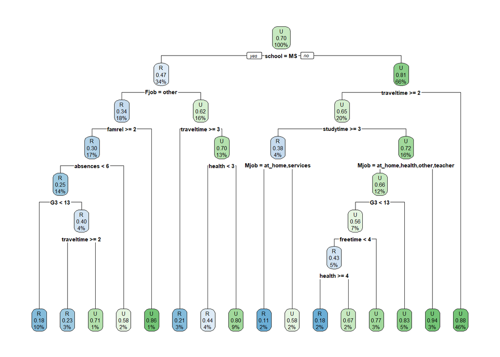

```r
rpart.plot(tree1)
```

```r
pred1 <- predict(tree1,newdata=test,type="class")
```

```r
reference <- test$address
u <- union(pred1, reference)
t <- table(factor(pred1, u), factor(reference, u))
confusionMatrix(t)
```

```
## Confusion Matrix and Statistics
##
##
##      U  R
##   U 95 21
##   R 19 28
##
##                Accuracy : 0.7546
##                  95% CI : (0.6812, 0.8185)
##     No Information Rate : 0.6994
##     P-Value [Acc > NIR] : 0.07128
##
##                   Kappa : 0.4095
##
##  Mcnemar's Test P-Value : 0.87437
##
##             Sensitivity : 0.8333
##             Specificity : 0.5714
##          Pos Pred Value : 0.8190
##          Neg Pred Value : 0.5957
##              Prevalence : 0.6994
##          Detection Rate : 0.5828
##    Detection Prevalence : 0.7117
##       Balanced Accuracy : 0.7024
##
##        'Positive' Class : U
##
```

```r
smp_size <- floor(0.75 * nrow(dataset))
set.seed(124)
train_ind <- sample(seq_len(nrow(dataset)), size = smp_size)

# tworzymy zbiory treningowe
train <- dataset[train_ind, ]
test <- dataset[-train_ind, ]
#Na podstawie szkoły do której chodzą uczniowie oraz czasu jaki zajumje im podróż do szkoły przewidujemy czy mieszkają w mieście czy na wsi
tree1 <- rpart(address ~ school + traveltime, data = train, method="class")
summary(tree1)
```

```
## Call:
## rpart(formula = address ~ school + traveltime, data = train,
##     method = "class")
##   n= 486
##
##           CP nsplit rel error    xerror       xstd
## 1 0.06756757      0 1.0000000 1.0000000 0.06855030
## 2 0.04729730      1 0.9324324 0.9256757 0.06701826
## 3 0.04054054      2 0.8851351 0.9459459 0.06745625
## 4 0.01000000      3 0.8445946 0.8851351 0.06609521
##
## Variable importance
##     school traveltime
##         77         23
##
## Node number 1: 486 observations,    complexity param=0.06756757
##   predicted class=U  expected loss=0.3045267  P(node) =1
##     class counts:   148   338
##    probabilities: 0.305 0.695
##   left son=2 (166 obs) right son=3 (320 obs)
##   Primary splits:
##       school     splits as  RL,      improve=25.66129, (0 missing)
##       traveltime < 1.5 to the right, improve=22.55483, (0 missing)
##   Surrogate splits:
##       traveltime < 1.5 to the right, agree=0.675, adj=0.048, (0 split)
##
## Node number 2: 166 observations,    complexity param=0.0472973
##   predicted class=R  expected loss=0.4698795  P(node) =0.3415638
##     class counts:    88    78
##    probabilities: 0.530 0.470
##   left son=4 (29 obs) right son=5 (137 obs)
##   Primary splits:
##       traveltime < 2.5 to the right, improve=4.860386, (0 missing)
##
## Node number 3: 320 observations
##   predicted class=U  expected loss=0.1875  P(node) =0.6584362
##     class counts:    60   260
##    probabilities: 0.188 0.812
##
## Node number 4: 29 observations
##   predicted class=R  expected loss=0.2068966  P(node) =0.05967078
##     class counts:    23     6
##    probabilities: 0.793 0.207
##
## Node number 5: 137 observations,    complexity param=0.04054054
##   predicted class=U  expected loss=0.4744526  P(node) =0.281893
##     class counts:    65    72
##    probabilities: 0.474 0.526
##   left son=10 (76 obs) right son=11 (61 obs)
##   Primary splits:
##       traveltime < 1.5 to the right, improve=1.443256, (0 missing)
##
## Node number 10: 76 observations
##   predicted class=R  expected loss=0.4605263  P(node) =0.1563786
##     class counts:    41    35
##    probabilities: 0.539 0.461
##
## Node number 11: 61 observations
##   predicted class=U  expected loss=0.3934426  P(node) =0.1255144
##     class counts:    24    37
##    probabilities: 0.393 0.607
```

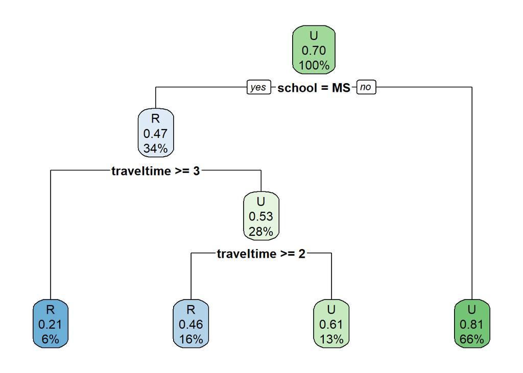

```r
rpart.plot(tree1)
```

```r
pred1 <- predict(tree1,newdata=test,type="class")
reference <- test$address
u <- union(pred1, reference)
t <- table(factor(pred1, u), factor(reference, u))
confusionMatrix(t)
```

```
## Confusion Matrix and Statistics
##
##
##       U   R
##   U 101  24
##   R  13  25
##
##                Accuracy : 0.773
##                  95% CI : (0.701, 0.8349)
##     No Information Rate : 0.6994
##     P-Value [Acc > NIR] : 0.02261
##
##                   Kappa : 0.4233
##
##  Mcnemar's Test P-Value : 0.10018
##
##             Sensitivity : 0.8860
##             Specificity : 0.5102
##          Pos Pred Value : 0.8080
##          Neg Pred Value : 0.6579
##              Prevalence : 0.6994
##          Detection Rate : 0.6196
##    Detection Prevalence : 0.7669
##       Balanced Accuracy : 0.6981
##
##        'Positive' Class : U
##
```

```r
str(data_classification)
```

```
## 'data.frame':    649 obs. of  44 variables:
##  $ school        : num [1:649, 1:2] 1 1 1 1 1 1 1 1 1 1 ...
##   ..- attr(*, "dimnames")=List of 2
##   .. ..$ : NULL
##   .. ..$ : chr [1:2] "GP" "MS"
##  $ sex           : num [1:649, 1:2] 1 1 1 1 1 0 0 1 0 0 ...
##   ..- attr(*, "dimnames")=List of 2
##   .. ..$ : NULL
##   .. ..$ : chr [1:2] "F" "M"
##  $ age           : num  1.031 0.21 -1.432 -1.432 -0.611 ...
##  $ address       : num [1:649, 1:2] 1 1 1 1 1 1 1 1 1 1 ...
##   ..- attr(*, "dimnames")=List of 2
##   .. ..$ : NULL
##   .. ..$ : chr [1:2] "U" "R"
##  $ famsize       : num [1:649, 1:2] 1 1 0 1 1 0 0 1 0 1 ...
```

[output cut: 45 more lines]

```r
k <- 5
folds <- sample(1:k, nrow(data_classification), replace=TRUE)

mean_cv_pred_err <- c()
for (cv_iter in 1:k){
  train <- data_raw[folds != cv_iter,]
  test <- data_raw[folds == cv_iter,]

  model <- data.random.forest <- randomForest(address ~ school + traveltime,
                                     data = train,
                                     proximity = TRUE)
  prediction <- predict(model, test)
  reference <- test$address
  u <- union(prediction, reference)
  t <- table(factor(prediction, u), factor(reference, u))
  acc <- confusionMatrix(t)$overall
  mean_cv_pred_err <- c(mean_cv_pred_err, acc["Accuracy"])
}
mean(mean_cv_pred_err)
```

```
## [1] 0.751918
```

```r
  model <- data.random.forest <- randomForest(address ~ school + traveltime,
                                     data = data_raw,
                                     proximity = TRUE)
  importance(model)
```

```
##            MeanDecreaseGini
## school             24.51436
## traveltime         22.29458
```

Ocena charakteru: school dodatni wpływ traveltime dodatni wpływ

##LDA

```r
smp_size <- floor(0.75 * nrow(dataset))
set.seed(124)
train_ind <- sample(seq_len(nrow(dataset)), size = smp_size)
train <- dataset[train_ind, ]
test <- dataset[-train_ind, ]

lda <- list()
lda$fit <- lda(address ~ school + traveltime, data = train)
lda$predicted <- predict(lda$fit, test)
confusionMatrix(table(lda$predicted$class, test$address))
```

```
## Confusion Matrix and Statistics
##
##
##      R  U
##   R 26 15
##   U 23 99
##
##                Accuracy : 0.7669
##                  95% CI : (0.6943, 0.8294)
##     No Information Rate : 0.6994
##     P-Value [Acc > NIR] : 0.03416
##
##                   Kappa : 0.4185
##
##  Mcnemar's Test P-Value : 0.25614
##
##             Sensitivity : 0.5306
##             Specificity : 0.8684
##          Pos Pred Value : 0.6341
##          Neg Pred Value : 0.8115
##              Prevalence : 0.3006
##          Detection Rate : 0.1595
##    Detection Prevalence : 0.2515
##       Balanced Accuracy : 0.6995
##
##        'Positive' Class : R
##
```

```r
lda$fit$scaling
```

```
##                  LD1
## schoolMS   -1.491714
## traveltime -0.913635
```

Zdolność predykcyjna: Accuracy : 0.7669

Ocena istotności predyktorów: school -1.491714 - bardziej istotny traveltime -0.913635

Ocena charakteru: school ujemny wpływ liniowy traveltime ujemny wpływ liniowy

##QDA

```r
smp_size <- floor(0.75 * nrow(dataset))
set.seed(124)
train_ind <- sample(seq_len(nrow(dataset)), size = smp_size)
train <- dataset[train_ind, ]
test <- dataset[-train_ind, ]

qda <- list()
qda$fit <- qda(address ~ school + traveltime, data = train)
qda$predicted <- predict(qda$fit, test)
confusionMatrix(table(qda$predicted$class, test$address))
```

```
## Confusion Matrix and Statistics
##
##
##      R  U
##   R 28 18
##   U 21 96
##
##                Accuracy : 0.7607
##                  95% CI : (0.6878, 0.824)
##     No Information Rate : 0.6994
##     P-Value [Acc > NIR] : 0.05007
##
##                   Kappa : 0.4209
##
##  Mcnemar's Test P-Value : 0.74877
##
##             Sensitivity : 0.5714
##             Specificity : 0.8421
##          Pos Pred Value : 0.6087
##          Neg Pred Value : 0.8205
##              Prevalence : 0.3006
##          Detection Rate : 0.1718
##    Detection Prevalence : 0.2822
##       Balanced Accuracy : 0.7068
##
##        'Positive' Class : R
##
```

```r
qda$fit$scaling
```

```
## , , R
##
##                   1          2
## schoolMS   -2.02989 -0.2438864
## traveltime  0.00000  1.1835661
##
## , , U
##
##                   1          2
## schoolMS   2.369951 -0.5065748
## traveltime 0.000000  1.6260426
```

Zdolność predykcyjna: Accuracy : 0.7607

Ocena istotności predyktorów: school najbardziej istotny traveltime mniej istotny

Ocena charakteru: school 2.369951 x - 0.5065748 x^2 traveltime 1.6260426 x^2 - dodatni

```r
dataset <- subset(dataset, select = -c(school))
```

```r
linear_fit <- lm(G3 ~ ., data = dataset)
summary(linear_fit)
```

```
##
## Call:
## lm(formula = G3 ~ ., data = dataset)
##
## Residuals:
##     Min      1Q  Median      3Q     Max
## -13.518  -1.312   0.071   1.487   6.881
##
## Coefficients:
##                   Estimate Std. Error t value Pr(>|t|)
## (Intercept)       7.660688   2.003004   3.825 0.000144 ***
## sexM             -0.535748   0.252961  -2.118 0.034587 *
## age               0.134365   0.103666   1.296 0.195417
## addressU          0.632626   0.256488   2.466 0.013918 *
## famsizeLE3        0.254428   0.248606   1.023 0.306516
## PstatusT          0.225042   0.351922   0.639 0.522760
## Medu              0.058215   0.153611   0.379 0.704837
## Fedu              0.184968   0.139849   1.323 0.186457
## Mjobhealth        0.997289   0.545456   1.828 0.067984 .
## Mjobother         0.058018   0.307642   0.189 0.850478
## Mjobservices      0.503480   0.378442   1.330 0.183883
## Mjobteacher       0.539120   0.509700   1.058 0.290601
## Fjobhealth       -0.404514   0.762625  -0.530 0.596012
## Fjobother         0.107450   0.458573   0.234 0.814819
## Fjobservices     -0.463747   0.485000  -0.956 0.339360
## Fjobteacher       0.926800   0.678184   1.367 0.172257
## reasonhome        0.116294   0.288967   0.402 0.687495
## reasonother      -0.648488   0.370224  -1.752 0.080343 .
## reasonreputation  0.335490   0.301470   1.113 0.266213
## guardianmother   -0.253609   0.268607  -0.944 0.345458
## guardianother     0.313239   0.537912   0.582 0.560564
## traveltime       -0.004981   0.160910  -0.031 0.975314
## studytime         0.472961   0.141329   3.347 0.000869 ***
## failures         -1.456988   0.207444  -7.024 5.79e-12 ***
## schoolsupyes     -1.107323   0.366841  -3.019 0.002646 **
## famsupyes        -0.019677   0.231846  -0.085 0.932390
## paidyes          -0.398780   0.468574  -0.851 0.395076
## activitiesyes     0.271796   0.226577   1.200 0.230771
## nurseryyes       -0.237719   0.275580  -0.863 0.388688
## higheryes         1.769031   0.388619   4.552 6.41e-06 ***
## internetyes       0.387091   0.278973   1.388 0.165780
## romanticyes      -0.481137   0.232527  -2.069 0.038951 *
## famrel            0.181031   0.117844   1.536 0.125010
## freetime         -0.152300   0.114040  -1.335 0.182214
## goout            -0.095639   0.108952  -0.878 0.380397
## Dalc             -0.222987   0.155394  -1.435 0.151805
## Walc             -0.069706   0.120280  -0.580 0.562443
## health           -0.171288   0.078317  -2.187 0.029114 *
## absences         -0.018384   0.024857  -0.740 0.459827
## ---
## Signif. codes:  0 '***' 0.001 '**' 0.01 '*' 0.05 '.' 0.1 ' ' 1
##
## Residual standard error: 2.707 on 610 degrees of freedom
## Multiple R-squared:  0.3392, Adjusted R-squared:  0.298
## F-statistic: 8.239 on 38 and 610 DF,  p-value: < 2.2e-16
```

```r
dataset_bs <- regsubsets(G3 ~ ., data=dataset, nvmax = 15)
summary(dataset_bs)
```

```
## Subset selection object
## Call: regsubsets.formula(G3 ~ ., data = dataset, nvmax = 15)
## 38 Variables  (and intercept)
##                  Forced in Forced out
## sexM                 FALSE      FALSE
## age                  FALSE      FALSE
## addressU             FALSE      FALSE
## famsizeLE3           FALSE      FALSE
## PstatusT             FALSE      FALSE
## Medu                 FALSE      FALSE
## Fedu                 FALSE      FALSE
## Mjobhealth           FALSE      FALSE
## Mjobother            FALSE      FALSE
## Mjobservices         FALSE      FALSE
## Mjobteacher          FALSE      FALSE
## Fjobhealth           FALSE      FALSE
## Fjobother            FALSE      FALSE
## Fjobservices         FALSE      FALSE
## Fjobteacher          FALSE      FALSE
## reasonhome           FALSE      FALSE
## reasonother          FALSE      FALSE
## reasonreputation     FALSE      FALSE
## guardianmother       FALSE      FALSE
## guardianother        FALSE      FALSE
## traveltime           FALSE      FALSE
## studytime            FALSE      FALSE
## failures             FALSE      FALSE
## schoolsupyes         FALSE      FALSE
## famsupyes            FALSE      FALSE
## paidyes              FALSE      FALSE
## activitiesyes        FALSE      FALSE
## nurseryyes           FALSE      FALSE
## higheryes            FALSE      FALSE
## internetyes          FALSE      FALSE
## romanticyes          FALSE      FALSE
## famrel               FALSE      FALSE
## freetime             FALSE      FALSE
## goout                FALSE      FALSE
## Dalc                 FALSE      FALSE
## Walc                 FALSE      FALSE
```

[output cut: 85 more lines]

```
## 1  ( 1 )  " "    " "      " "   " "  " "  " "    " "
## 2  ( 1 )  " "    " "      " "   " "  " "  " "    " "
## 3  ( 1 )  " "    " "      " "   " "  " "  " "    " "
## 4  ( 1 )  " "    " "      " "   " "  " "  " "    " "
## 5  ( 1 )  " "    " "      " "   "*"  " "  " "    " "
## 6  ( 1 )  " "    " "      " "   "*"  " "  " "    " "
## 7  ( 1 )  " "    " "      " "   "*"  " "  " "    " "
## 8  ( 1 )  " "    " "      " "   "*"  " "  " "    " "
## 9  ( 1 )  " "    " "      " "   "*"  " "  "*"    " "
## 10  ( 1 ) " "    " "      " "   "*"  " "  "*"    " "
## 11  ( 1 ) " "    " "      " "   "*"  " "  "*"    " "
## 12  ( 1 ) " "    " "      " "   "*"  " "  " "    " "
## 13  ( 1 ) " "    " "      " "   "*"  " "  "*"    " "
## 14  ( 1 ) " "    " "      " "   "*"  " "  "*"    " "
## 15  ( 1 ) " "    " "      " "   "*"  " "  "*"    " "
```

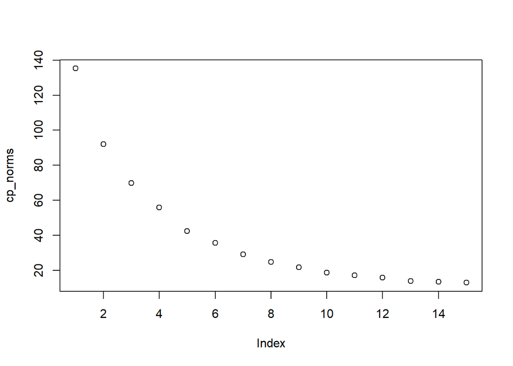

```r
cp_norms = summary(dataset_bs)$cp
plot(cp_norms)
```

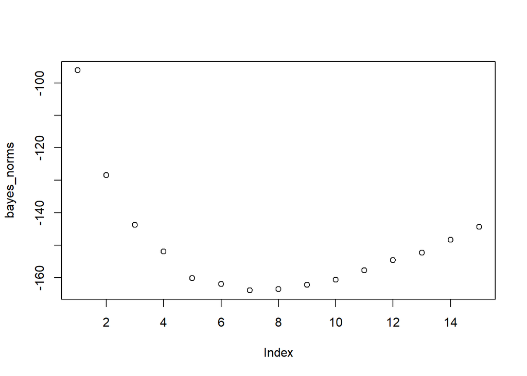

```r
bayes_norms = summary(dataset_bs)$bic
plot(bayes_norms)
```

```r
coef(dataset_bs, id = 5)
```

```
## (Intercept)        Medu   studytime    failures   higheryes        Dalc
##   9.2479316   0.3994994   0.5627737  -1.5308490   1.7872724  -0.4597146
```

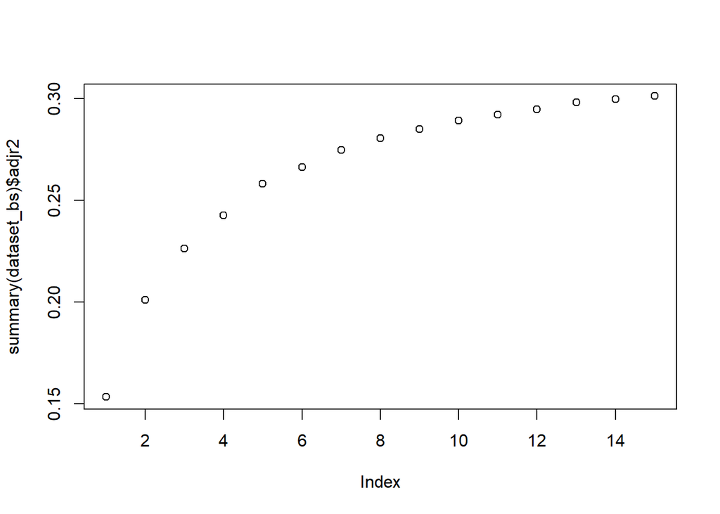

```r
plot(summary(dataset_bs)$adjr2)
```

```r
predict.regsubsets <- function(object, newdata, id, ...) {
  model_formula <- as.formula(object$call[[2]])
  mat <- model.matrix(model_formula, newdata)
  coefs <- coef(object, id = id)
  mat[, names(coefs)] %*% coefs
}

prediction_error <- function(i, model, subset) {
  pred <- predict(model, dataset[subset,], id = i)
  mean((dataset$G3[subset] - pred)^2)
}
```

Szukanie optymalnej liczby predyktorów przy użyciu walidacji krzyżowej:

```r
k <- 10
max_predictors <- 10

folds <- sample(1:k, nrow(dataset), replace=TRUE)#dzielimy nasz zbior na podzbiory do k-krotnej walidacji krzyzowej
val_err <- NULL

for (j in 1:k) {
  fit_bs <- regsubsets(G3 ~ ., data=dataset[folds!=j,], nvmax=max_predictors)
  err <- sapply(1:max_predictors, prediction_error, model = fit_bs, subset = (folds == j))
  val_err <- rbind(val_err, err)
}
colMeans(val_err)
```

```
##  [1] 8.865154 8.498163 8.225076 8.282702 8.181388 8.286313 8.345996 8.275190
##  [9] 8.355714 8.363240
```

```r
summary(lm(G3 ~ failures + higher + studytime + Dalc + Medu, data = dataset))
```

```
##
## Call:
## lm(formula = G3 ~ failures + higher + studytime + Dalc + Medu,
##     data = dataset)
##
## Residuals:
##      Min       1Q   Median       3Q      Max
## -13.2990  -1.5000   0.0627   1.6632   6.3592
##
## Coefficients:
##             Estimate Std. Error t value Pr(>|t|)
## (Intercept)  9.24793    0.51638  17.909  < 2e-16 ***
## failures    -1.53085    0.19620  -7.803 2.46e-14 ***
## higheryes    1.78727    0.38368   4.658 3.88e-06 ***
## studytime    0.56277    0.13579   4.144 3.86e-05 ***
## Dalc        -0.45971    0.12032  -3.821 0.000146 ***
## Medu         0.39950    0.09945   4.017 6.59e-05 ***
## ---
## Signif. codes:  0 '***' 0.001 '**' 0.01 '*' 0.05 '.' 0.1 ' ' 1
##
## Residual standard error: 2.782 on 643 degrees of freedom
## Multiple R-squared:  0.264,  Adjusted R-squared:  0.2583
## F-statistic: 46.12 on 5 and 643 DF,  p-value: < 2.2e-16
```

Konwersja predyktorów jakościowych na ich odpowiedniki liczbowe:

```r
dataset$higherYes <- ifelse(dataset$higher=="yes", 1, 0)

failures_max_degree <- length(unique(dataset$failures)) - 1
higherYes_max_degree <- length(unique(dataset$higherYes)) - 1
studtytime_max_degree <- length(unique(dataset$studytime)) - 1
Dalc_max_degree <- length(unique(dataset$Dalc)) - 1
Medu_max_degree <- length(unique(dataset$Medu)) - 1
```

Postanowiliśmy sprawdzić jaki może być optymalny stopień wielomianu dla poszczególnych predyktorów:

```r
set.seed(2)
k <- 5
folds <- sample(1:k, nrow(dataset), replace=TRUE)

results <- data.frame(failures_degree=numeric(), higherYes_degree=numeric(), studytime_degree=numeric(), Dalc_degree=numeric(), Medu_degree=numeric(), test_error=numeric())

for (d_1 in 1:failures_max_degree){
  for (d_2 in 1:higherYes_max_degree){
    for (d_3 in 1:studtytime_max_degree){
      for (d_4 in 1:Dalc_max_degree){
        for (d_5 in 1:Medu_max_degree){
          mean_cv_pred_err <- c()
          for (cv_iter in 1:k){
            train <- dataset[folds != cv_iter,]
            test <- dataset[folds == cv_iter,]
            linear_fit <- lm(G3 ~ poly(failures, d_1) + poly(higherYes, d_2) + poly(studytime, d_3) + poly(Dalc, d_4)
                       + poly(Medu, d_5), data = train)
            mean_cv_pred_err <- c(mean_cv_pred_err, c(mean((test$G3 - predict(linear_fit, test))^2)))
          }
          results[nrow(results) +1,] = c(d_1, d_2, d_3, d_4, d_5, mean(mean_cv_pred_err))
        }
      }
    }
  }
}
```

```r
results[order(results$test_error, decreasing = FALSE),]
```

```
##     failures_degree higherYes_degree studytime_degree Dalc_degree Medu_degree
## 65                2                1                2           1           1
## 49                2                1                1           1           1
## 66                2                1                2           1           2
## 81                2                1                3           1           1
## 68                2                1                2           1           4
## 50                2                1                1           1           2
## 67                2                1                2           1           3
## 82                2                1                3           1           2
## 52                2                1                1           1           4
## 84                2                1                3           1           4
## 51                2                1                1           1           3
## 113               3                1                2           1           1
## 83                2                1                3           1           3
## 97                3                1                1           1           1
```

[output cut: 275 more lines]

Z powyższej tabeli zawierającej posortowane błędy względem stopnia wielomianu wynika, że stopień studytime oraz Dalc nie ma aż tak duzego znaczenia, dlatego postanawiamy tutaj nie komplikować modelu, gdyż może to wpłynąć na zwiększenie wariancji. Postanawiamy wykorzystać poniższe stopnie wielomianóW: failures: 2 higherYes: 1 studytime: 1 Dalc: 1 Medu: 1

```r
lm_fit <- lm(G3 ~ poly(failures, 2) + higherYes + studytime + Dalc + Medu, data = dataset)
summary(lm_fit)
```

```
##
## Call:
## lm(formula = G3 ~ poly(failures, 2) + higherYes + studytime +
##     Dalc + Medu, data = dataset)
##
## Residuals:
##     Min      1Q  Median      3Q     Max
## -13.304  -1.508   0.079   1.696   6.365
##
## Coefficients:
##                     Estimate Std. Error t value Pr(>|t|)
## (Intercept)          9.08878    0.49922  18.206  < 2e-16 ***
## poly(failures, 2)1 -23.67661    2.92860  -8.085 3.11e-15 ***
## poly(failures, 2)2  11.63033    2.78056   4.183 3.28e-05 ***
## higherYes            1.68772    0.37960   4.446 1.03e-05 ***
## studytime            0.55668    0.13409   4.152 3.75e-05 ***
## Dalc                -0.43407    0.11896  -3.649 0.000285 ***
## Medu                 0.35245    0.09884   3.566 0.000390 ***
## ---
## Signif. codes:  0 '***' 0.001 '**' 0.01 '*' 0.05 '.' 0.1 ' ' 1
##
## Residual standard error: 2.747 on 642 degrees of freedom
## Multiple R-squared:  0.2835, Adjusted R-squared:  0.2768
## F-statistic: 42.34 on 6 and 642 DF,  p-value: < 2.2e-16
```

Otrzymaliśmy błąd testowy o wartości:

```r
set.seed(2)
k <- 5
folds <- sample(1:k, nrow(dataset), replace=TRUE)

mean_cv_pred_err <- c()
for (cv_iter in 1:k){
  train <- dataset[folds != cv_iter,]
  test <- dataset[folds == cv_iter,]
  linear_fit <- lm(G3 ~ poly(failures, 2) + higherYes + studytime + Dalc + Medu, data = train)
  mean_cv_pred_err <- c(mean_cv_pred_err, c(mean((test$G3 - predict(linear_fit, test))^2)))
}
mean(mean_cv_pred_err)
```

```
## [1] 7.617935
```

Dla otrzymanych wartości współczynników postanowiliśmy przeprowadzić również regularyzację: Rozpoczęliśmy od szukania optymalnego lambda dla regresji grzbietowej przy użyciu k-krotnej walidacji krzyżowej:

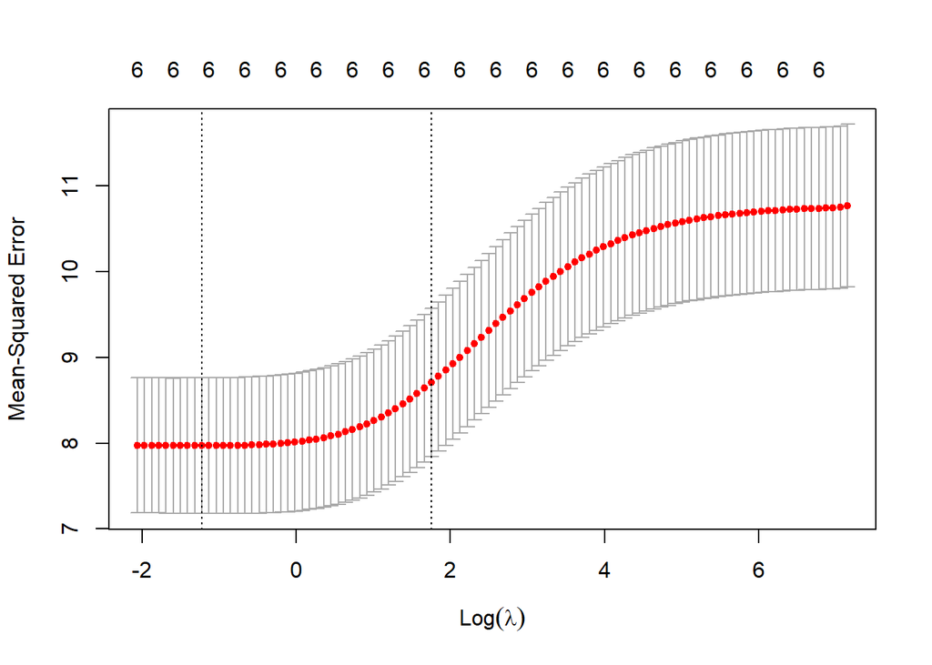

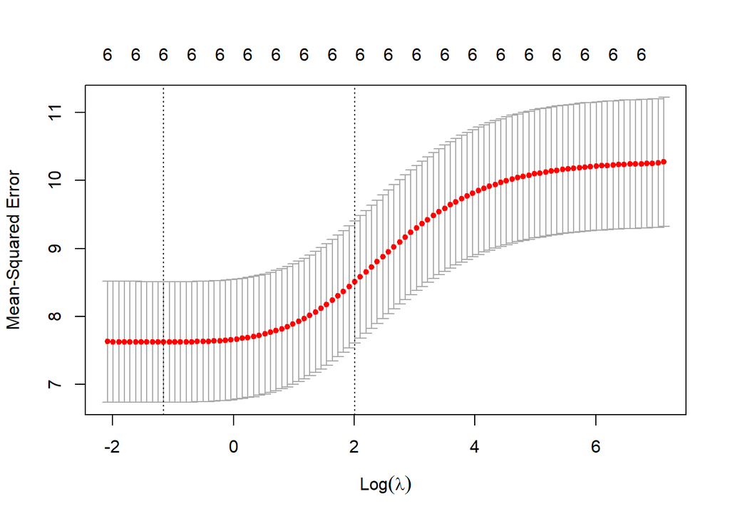

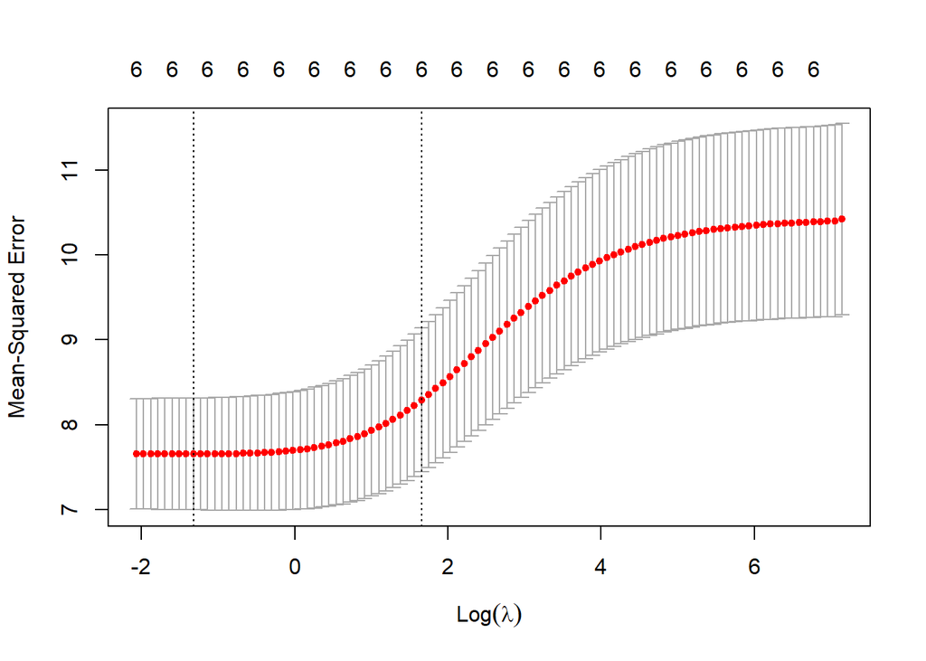

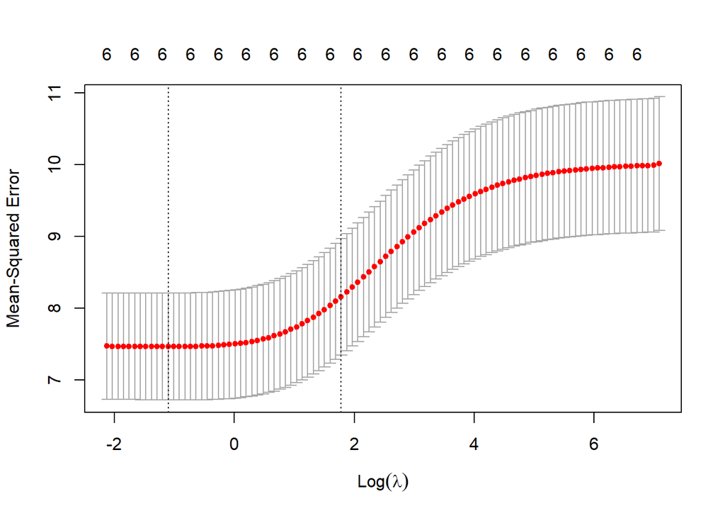

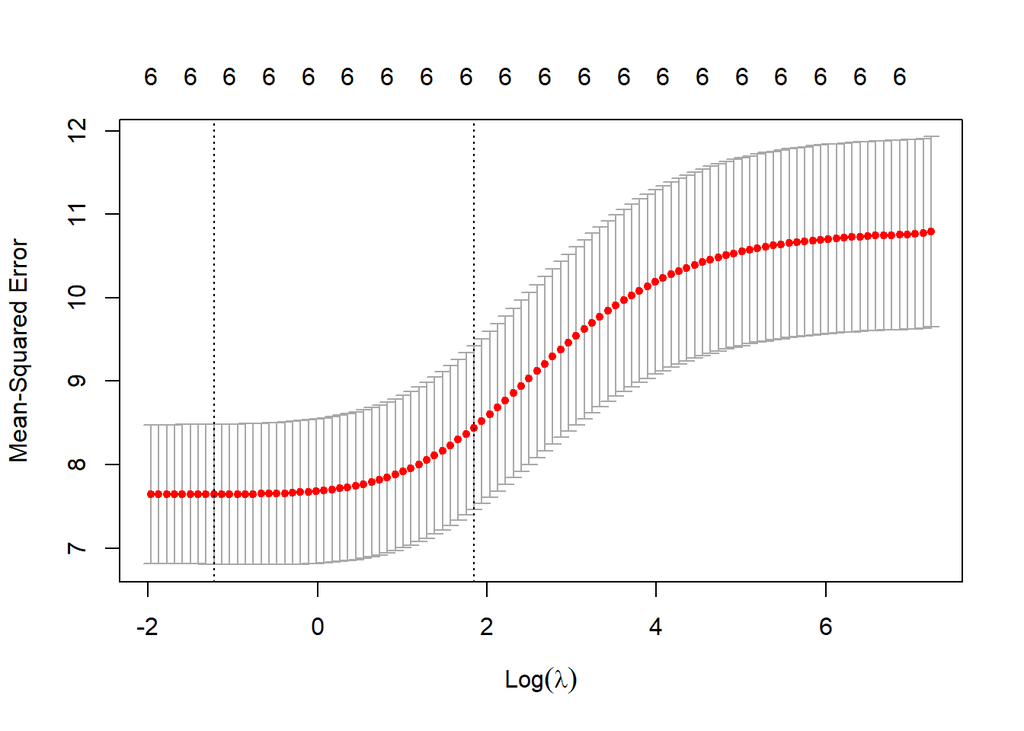

```r
X <- model.matrix(G3 ~ poly(failures, 2) + higherYes + studytime + Dalc + Medu, data = dataset)[, -1]
y <- dataset$G3

set.seed(2)
k <- 5

folds <- sample(1:k, nrow(X), replace=TRUE)

lambdas = c()
for (i in 1:k){
  cv_out <- cv.glmnet(X[folds!=i,], y[folds!=i], alpha = 0)
  lambdas = c(lambdas, cv_out$lambda.min)
  plot(cv_out)
}
```

```r
opt_lambda <- mean(lambdas)
opt_lambda
```

```
## [1] 0.3003844
```

Optymalna lambda wyniosła więc 0.3003844.

Bład testowy dla otrzymanej lambdy:

```r
set.seed(2)
lambda_grid <- 10^seq(10, -2, length.out = 100)
fit_ridge_full <- glmnet(X, y, alpha = 0)

k <- 5
folds <- sample(1:k, nrow(X), replace=TRUE)

test_errors = c()
for (i in 1:k){
  pred_ridge_opt <- predict(fit_ridge_full, s = opt_lambda, newx = X[folds==i,])
  mean_pred_error <- mean((pred_ridge_opt - y[folds==i])^2)
  test_errors = c(test_errors, mean_pred_error)
}
mean(test_errors)
```

```
## [1] 7.460874
```

```r
predict(fit_ridge_full, s = opt_lambda, type = "coefficients")
```

```
## 7 x 1 sparse Matrix of class "dgCMatrix"
##                              1
## (Intercept)          9.1776269
## poly(failures, 2)1 -21.9444528
## poly(failures, 2)2  10.7563466
## higherYes            1.6456224
## studytime            0.5291805
## Dalc                -0.4111225
## Medu                 0.3394856
```

Błąd spadł

Zdolność predykcyjna: RSS: 7.460874

Ocena istotności predyktorów: poly(failures, 2)1 -21.9444528 - największy poly(failures, 2)2 10.7563466 higherYes 1.6456224 studytime 0.5291805 Dalc -0.4111225 Medu 0.3394856 - najmniejszy

Ocena charakteru: failures - ujemny kwadratowy higherYes - dodatni liniowy studytime - dodatni liniowy Dalc - ujemny liniowy Medu - dodatni liniowy

Próba regularyzacji pozwoliła nam jeszcze bardziej zmniejszyć błąd testowy.

Postanowiliśmy również porównać nasz model z modelem czysto liniowym:

```r
set.seed(2)
k <- 5
folds <- sample(1:k, nrow(dataset), replace=TRUE)

lower_stds <- c()
mean_cv_pred_err <- c()
higher_stds <- c()
for (cv_iter in 1:k){
  train <- dataset[folds != cv_iter,]
  test <- dataset[folds == cv_iter,]

  model <- lm(G3 ~ failures + higherYes + studytime + Dalc + Medu, data = train)

  prediction <- predict(model, test, se.fit=TRUE)
  mean_pred <- mean((test$G3 - prediction$fit)^2)
  #higher_std <- mean(((test$G3 - model$fit) + 2 * model$se.fit)^2)
  #lower_std <- mean(((test$G3 - model$fit) - 2 * model$se.fit)^2)
  mean_cv_pred_err <- c(mean_cv_pred_err, c(mean_pred))
}
mean(mean_cv_pred_err)
```

```
## [1] 7.888937
```

```r
summary(lm(G3 ~ failures + higherYes + studytime + Dalc + Medu, data = dataset))
```

```
##
## Call:
## lm(formula = G3 ~ failures + higherYes + studytime + Dalc + Medu,
##     data = dataset)
##
## Residuals:
##      Min       1Q   Median       3Q      Max
## -13.2990  -1.5000   0.0627   1.6632   6.3592
##
## Coefficients:
##             Estimate Std. Error t value Pr(>|t|)
## (Intercept)  9.24793    0.51638  17.909  < 2e-16 ***
## failures    -1.53085    0.19620  -7.803 2.46e-14 ***
## higherYes    1.78727    0.38368   4.658 3.88e-06 ***
## studytime    0.56277    0.13579   4.144 3.86e-05 ***
## Dalc        -0.45971    0.12032  -3.821 0.000146 ***
## Medu         0.39950    0.09945   4.017 6.59e-05 ***
## ---
## Signif. codes:  0 '***' 0.001 '**' 0.01 '*' 0.05 '.' 0.1 ' ' 1
##
## Residual standard error: 2.782 on 643 degrees of freedom
## Multiple R-squared:  0.264,  Adjusted R-squared:  0.2583
## F-statistic: 46.12 on 5 and 643 DF,  p-value: < 2.2e-16
```

Zdolność predykcyjna: RSS: 7.888937

Ocena istotności predyktorów: failures 2.46e-14 - najbardziej istotny higherYes 3.88e-06 studytime 3.86e-05 Dalc 0.000146 - najmniej istotny Medu 6.59e-05

Ocena charakteru: failures - ujemny liniowy higherYes - dodatni liniowy studytime - dodatni liniowy Dalc - ujemny liniowy Medu - dodatni liniowy

Bład wzrósł

Następnie postanowiliśmy poprawić rezultat naszej predykcji, wykorzystując do tego funkcje sklejane: Postanowiliśmy znaleźć najbardziej pasującą liczbę stopni swobody przy użyciu walidacji krzyżowej:

```r
#failures_max <- 7
#higherYes_max <- 7
#studtytime_max <- 7
#Dalc_max <- 7
#Medu_max <- 7
#
#for (d_1 in 4:failures_max){
#  for (d_2 in 4:higherYes_max){
#    for (d_3 in 4:studtytime_max){
#      for (d_4 in 4:Dalc_max){
#        for (d_5 in 4:Medu_max){
#          mean_cv_pred_err <- c()
#          for (cv_iter in 1:k){
#            train <- dataset[folds != cv_iter,]
#            test <- dataset[folds == cv_iter,]
#
#            model <- lm(G3 ~ bs(failures, df = d_1) + bs(higherYes, df = d_2) + bs(studytime, df = d_3) + bs(Dalc, df=d_4) + bs(Medu, df=d_5) #, data = train)
#
#            mean_cv_pred_err <- c(mean_cv_pred_err, c(mean((test$G3 - predict(model, test))^2)))
#          }
#          results[nrow(results) +1,] = c(d_1, d_2, d_3, d_4, d_5, mean(mean_cv_pred_err))
#        }
#      }
#    }
#  }
#}
```

```r
#results[order(results$test_error, decreasing = FALSE),]
```

Postanowiliśmy wykorzystać splajny naturalne:

```r
set.seed(2)
k <- 5
folds <- sample(1:k, nrow(dataset), replace=TRUE)

mean_cv_pred_err <- c()
for (cv_iter in 1:k){
  train <- dataset[folds != cv_iter,]
  test <- dataset[folds == cv_iter,]

  model <- lm(G3 ~ ns(failures) + ns(higherYes) + ns(studytime) + ns(Dalc) + ns(Medu) , data = train)

  prediction <- predict(model, test, se.fit=TRUE)
  mean_pred <- mean((test$G3 - prediction$fit)^2)
  mean_cv_pred_err <- c(mean_cv_pred_err, c(mean_pred))
}
mean(mean_cv_pred_err)
```

```
## [1] 7.888937
```

```r
summary(lm(G3 ~ ns(failures) + ns(higherYes) + ns(studytime) + ns(Dalc) + ns(Medu) , data = dataset))
```

```
##
## Call:
## lm(formula = G3 ~ ns(failures) + ns(higherYes) + ns(studytime) +
##     ns(Dalc) + ns(Medu), data = dataset)
##
## Residuals:
##      Min       1Q   Median       3Q      Max
## -13.2990  -1.5000   0.0627   1.6632   6.3592
##
## Coefficients:
##               Estimate Std. Error t value Pr(>|t|)
## (Intercept)     9.3510     0.4311  21.690  < 2e-16 ***
## ns(failures)   -5.7279     0.7341  -7.803 2.46e-14 ***
## ns(higherYes)   2.2291     0.4785   4.658 3.88e-06 ***
## ns(studytime)   2.1057     0.5081   4.144 3.86e-05 ***
## ns(Dalc)       -2.2935     0.6002  -3.821 0.000146 ***
## ns(Medu)        1.9931     0.4962   4.017 6.59e-05 ***
## ---
## Signif. codes:  0 '***' 0.001 '**' 0.01 '*' 0.05 '.' 0.1 ' ' 1
##
## Residual standard error: 2.782 on 643 degrees of freedom
## Multiple R-squared:  0.264,  Adjusted R-squared:  0.2583
## F-statistic: 46.12 on 5 and 643 DF,  p-value: < 2.2e-16
```

Zdolność predykcyjna: RSS: 7.888937

Ocena istotności predyktorów: failures 2.46e-14 - najbardziej istotny higherYes 3.88e-06 studytime 3.86e-05 Dalc 0.000146 - najmniej istotny Medu 6.59e-05

Ocena charakteru: failures - ujemny higherYes - dodatni studytime - dodatni Dalc - ujemny Medu - dodatni

Splajny zwykłe:

```r
set.seed(2)
k <- 5
folds <- sample(1:k, nrow(dataset), replace=TRUE)

mean_cv_pred_err <- c()
for (cv_iter in 1:k){
  train <- dataset[folds != cv_iter,]
  test <- dataset[folds == cv_iter,]

  model <- lm(G3 ~ bs(failures) + bs(higherYes) + bs(studytime) + bs(Dalc) + bs(Medu) , data = train)

  prediction <- predict(model, test, se.fit=TRUE)
  mean_pred <- mean((test$G3 - prediction$fit)^2)
  mean_cv_pred_err <- c(mean_cv_pred_err, c(mean_pred))
}
mean(mean_cv_pred_err)
```

```
## [1] 7.772781
```

```r
summary(lm(G3 ~ bs(failures) + bs(higherYes) + bs(studytime) + bs(Dalc) + bs(Medu) , data = dataset))
```

```
##
## Call:
## lm(formula = G3 ~ bs(failures) + bs(higherYes) + bs(studytime) +
##     bs(Dalc) + bs(Medu), data = dataset)
##
## Residuals:
##      Min       1Q   Median       3Q      Max
## -13.3739  -1.4315   0.1006   1.6261   6.5409
##
## Coefficients: (2 not defined because of singularities)
##                Estimate Std. Error t value Pr(>|t|)
## (Intercept)    10.48546    1.04642  10.020  < 2e-16 ***
## bs(failures)1  -5.64575    1.49596  -3.774 0.000176 ***
## bs(failures)2  -1.13963    2.24786  -0.507 0.612342
## bs(failures)3  -3.20810    0.76367  -4.201 3.04e-05 ***
## bs(higherYes)1       NA         NA      NA       NA
## bs(higherYes)2       NA         NA      NA       NA
## bs(higherYes)3  1.68050    0.38438   4.372 1.44e-05 ***
## bs(studytime)1 -0.05628    0.74696  -0.075 0.939968
## bs(studytime)2  2.23870    0.96835   2.312 0.021104 *
## bs(studytime)3  1.25774    0.50916   2.470 0.013764 *
## bs(Dalc)1      -0.62709    0.92915  -0.675 0.499979
## bs(Dalc)2      -1.62278    1.45865  -1.113 0.266335
## bs(Dalc)3      -1.39148    0.67954  -2.048 0.041002 *
## bs(Medu)1      -0.95329    2.03538  -0.468 0.639688
## bs(Medu)2       0.13709    0.83136   0.165 0.869074
## bs(Medu)3       0.68891    1.00508   0.685 0.493324
## ---
## Signif. codes:  0 '***' 0.001 '**' 0.01 '*' 0.05 '.' 0.1 ' ' 1
##
## Residual standard error: 2.749 on 635 degrees of freedom
## Multiple R-squared:  0.2904, Adjusted R-squared:  0.2758
## F-statistic: 19.99 on 13 and 635 DF,  p-value: < 2.2e-16
```

W obu przypadkach błędy były większe niż w przypadku regularyzowanej regresji liniowej.

Zdolność predykcyjna: RSS: 7.772781

Ocena charakteru: failures - sześcienny ujemny higherYes - liniowy dodatni studytime - sześcienny dodatni Dalc - sześcienny ujemny Medu - sześcienny dodatni

```r
medv_tree <- rpart(G3 ~ ., data = dataset)
summary(medv_tree)
```

```
## Call:
## rpart(formula = G3 ~ ., data = dataset)
##   n= 649
##
##            CP nsplit rel error    xerror       xstd
## 1  0.19219731      0 1.0000000 1.0027028 0.08531986
## 2  0.03913613      1 0.8078027 0.8132328 0.06936367
## 3  0.02180961      2 0.7686666 0.7753459 0.07007110
## 4  0.02009148      3 0.7468569 0.8184568 0.07187097
## 5  0.01801485      4 0.7267655 0.8313666 0.07300978
## 6  0.01759248      5 0.7087506 0.8479617 0.07460021
## 7  0.01398589      6 0.6911581 0.8423102 0.07478156
## 8  0.01244227      7 0.6771722 0.8033806 0.06973891
## 9  0.01158950      9 0.6522877 0.8122984 0.07087236
## 10 0.01106533     10 0.6406982 0.8091184 0.07101072
## 11 0.01000000     11 0.6296329 0.8086953 0.07103504
##
## Variable importance
##   failures     higher  higherYes  schoolsup   absences       Dalc       Walc
##         40          8          8          6          5          5          5
##        age  studytime       Fedu   freetime    address      goout       Medu
##          5          4          4          3          2          1          1
##       Fjob        sex traveltime
##          1          1          1
##
## Node number 1: 649 observations,    complexity param=0.1921973
##   mean=11.90601, MSE=10.42106
##   left son=2 (100 obs) right son=3 (549 obs)
##   Primary splits:
##       failures  < 0.5  to the right, improve=0.19219730, (0 missing)
##       higherYes < 0.5  to the left,  improve=0.11033800, (0 missing)
##       higher    splits as  LR,       improve=0.11033800, (0 missing)
##       studytime < 1.5  to the left,  improve=0.05247125, (0 missing)
##       Medu      < 3.5  to the left,  improve=0.04788288, (0 missing)
##   Surrogate splits:
##       age      < 18.5 to the right, agree=0.863, adj=0.11, (0 split)
##       guardian splits as  RRL,      agree=0.847, adj=0.01, (0 split)
##       absences < 25   to the right, agree=0.847, adj=0.01, (0 split)
##
## Node number 2: 100 observations,    complexity param=0.02180961
```

[output cut: 147 more lines]

```
##       address splits as  LR,       improve=0.06481447, (0 missing)
##       goout   < 1.5  to the left,  improve=0.04909327, (0 missing)
##       reason  splits as  RRLR,     improve=0.03813575, (0 missing)
##       Medu    < 3.5  to the left,  improve=0.03631200, (0 missing)
##       Mjob    splits as  LRRRR,    improve=0.03345436, (0 missing)
##   Surrogate splits:
##       traveltime < 2.5  to the right, agree=0.832, adj=0.205, (0 split)
##       Medu       < 1.5  to the left,  agree=0.804, adj=0.077, (0 split)
##       internet   splits as  LR,       agree=0.804, adj=0.077, (0 split)
##
## Node number 238: 39 observations
##   mean=12.05128, MSE=9.279421
##
## Node number 239: 145 observations
##   mean=13.64828, MSE=5.303876
```

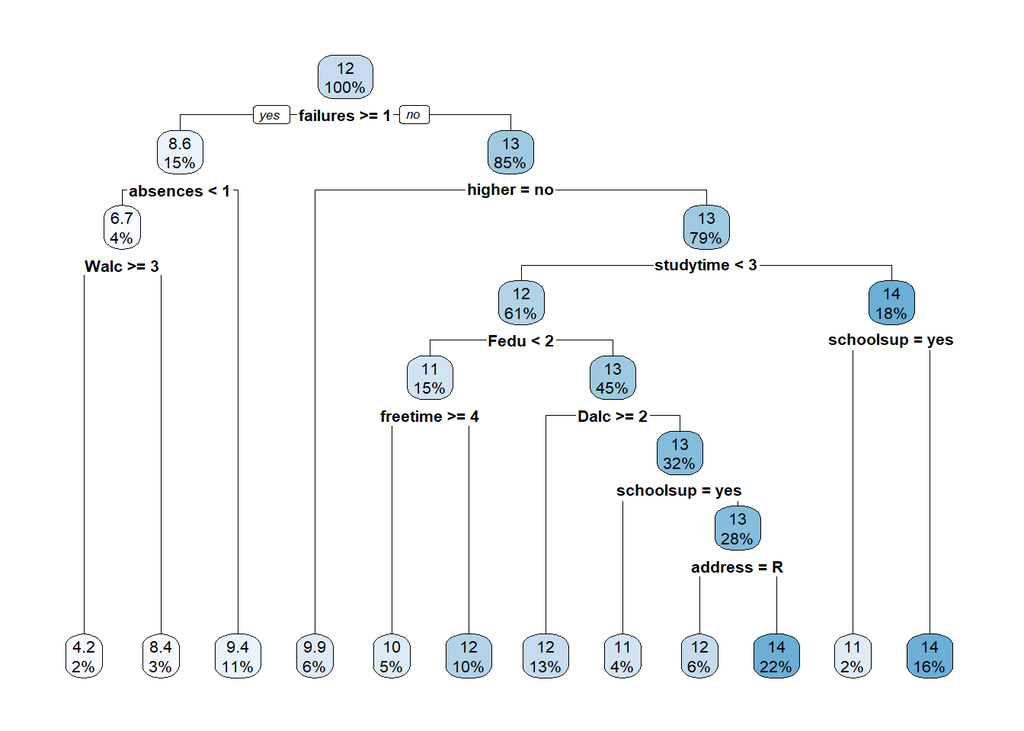

```r
rpart.plot(medv_tree)
```

```r
set.seed(2)
k <- 5
folds <- sample(1:k, nrow(dataset), replace=TRUE)

mean_cv_pred_err <- c()
for (cv_iter in 1:k){
  train <- dataset[folds != cv_iter,]
  test <- dataset[folds == cv_iter,]

  model <- tree(G3 ~ ., data = dataset)

  prediction <- predict(model, test)
  mean_pred <- mean((test$G3 - prediction)^2)
  mean_cv_pred_err <- c(mean_cv_pred_err, c(mean_pred))
}
mean(mean_cv_pred_err)
```

```
## [1] 6.429021
```

Wykorzystanie drzewa regresyjnego jeszcze bardziej poprawiło błąd tesowy.

Zdolność predykcyjna: RSS: 6.429021

Ocena charakteru: Koniunkcja warunków

Chcieliśmy również wypróbować metody prunningu:

```r
medv_tree <- tree(G3 ~ ., data = dataset)
medv_cv <- cv.tree(medv_tree)
```

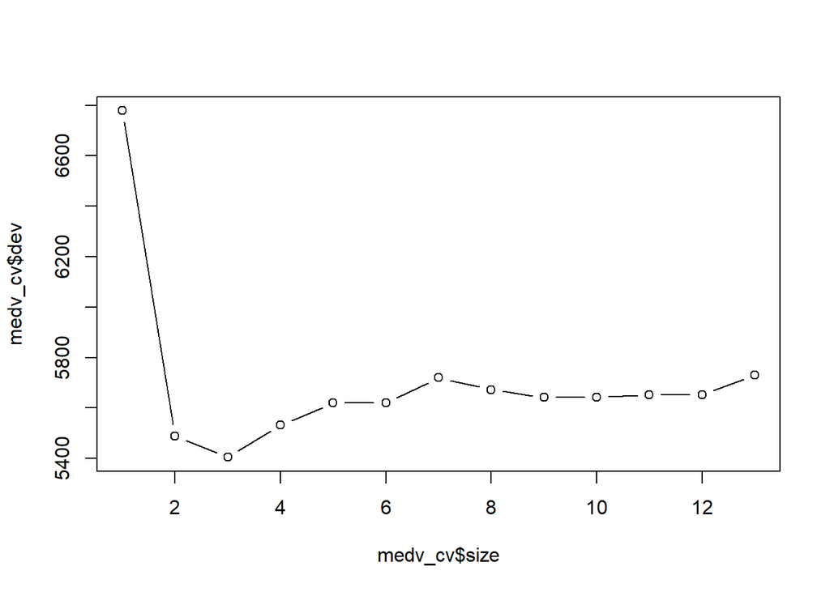

```r
plot(medv_cv$size, medv_cv$dev, type = "b")
```

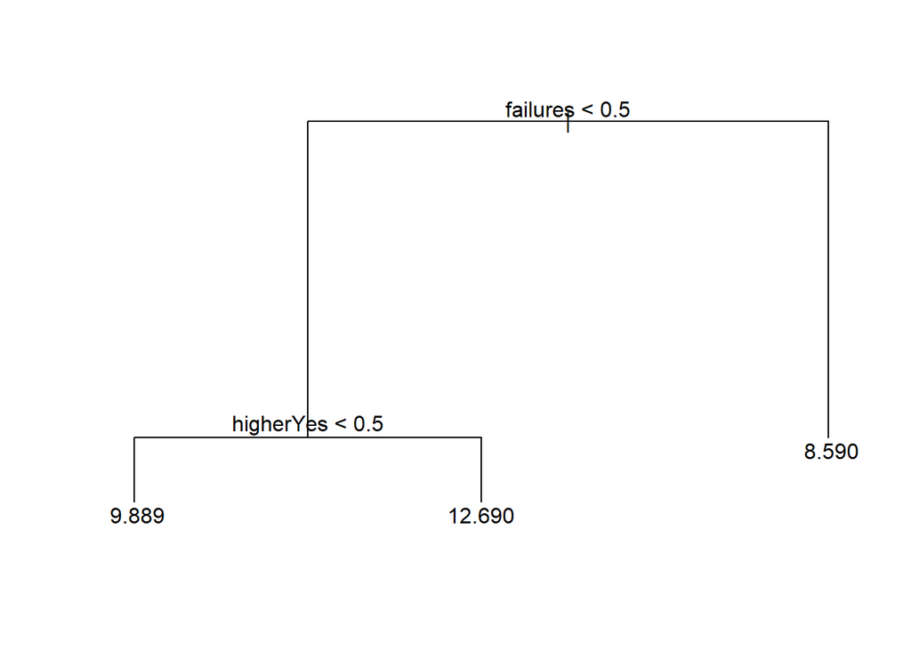

```r
medv_pruned <- prune.tree(medv_tree, best = 3)
plot(medv_pruned)
text(medv_pruned)
```

```r
set.seed(2)
k <- 5
folds <- sample(1:k, nrow(dataset), replace=TRUE)

mean_cv_pred_err <- c()
for (cv_iter in 1:k){
  train <- dataset[folds != cv_iter,]
  test <- dataset[folds == cv_iter,]

  model <- prune.tree(tree(G3 ~ ., data = dataset), best=3)

  prediction <- predict(model, test)
  mean_pred <- mean((test$G3 - prediction)^2)
  mean_cv_pred_err <- c(mean_cv_pred_err, c(mean_pred))
}
mean(mean_cv_pred_err)
```

```
## [1] 7.983812
```

Zdolność predykcyjna: RSS: 7.983812

Ocena istotności predyktorów: failures - największy higherYes - mniejszy

Ocena charakteru: Koniunkcja warunków

Wypróbowaliśmy jeszcze metody random forest:

```r
k <- 5
folds <- sample(1:k, nrow(dataset), replace=TRUE)

mean_cv_pred_err <- c()
for (cv_iter in 1:k){
  train <- dataset[folds != cv_iter,]
  test <- dataset[folds == cv_iter,]

  model <- data.random.forest <- randomForest(G3 ~ .,
                                     data = train,
                                     proximity = TRUE)
  prediction <- predict(model, test)
  mean_pred <- mean((test$G3 - prediction)^2)
  mean_cv_pred_err <- c(mean_cv_pred_err, c(mean_pred))
}
mean(mean_cv_pred_err)
```

```
## [1] 7.095927
```

```r
forest_full <- randomForest(G3 ~ .,
                                     data = dataset,
                                     proximity = TRUE)
importance(forest_full)
```

```
##            IncNodePurity
## sex            108.64922
## age            274.60374
## address        128.16199
## famsize         64.55889
## Pstatus         49.60223
## Medu           257.85952
## Fedu           237.41019
## Mjob           207.99494
## Fjob           189.68582
## reason         219.77696
## guardian        87.99806
## traveltime     149.44681
## studytime      263.63628
## failures       917.62799
## schoolsup      123.67271
## famsup          99.58802
## paid            28.74166
## activities      89.54433
## nursery         77.72397
## higher         265.09529
## internet        95.75464
## romantic        89.54515
## famrel         235.97081
## freetime       265.36839
## goout          334.58964
## Dalc           251.95300
## Walc           254.15782
## health         222.60688
## absences       372.36810
## higherYes      219.78952
```

Ocena charakteru: Koniunkcja warunków